# Clustering and classification of Boston data set (Week 4)

## Loading the data

First, I load the Boston data set from the MASS package and explore its structure and dimensions,

```r
# access the MASS package
library(MASS)

# load the data
data("Boston")

# explore the dataset
str(Boston)
```

```
## 'data.frame':    506 obs. of  14 variables:
##  $ crim   : num  0.00632 0.02731 0.02729 0.03237 0.06905 ...
##  $ zn     : num  18 0 0 0 0 0 12.5 12.5 12.5 12.5 ...
##  $ indus  : num  2.31 7.07 7.07 2.18 2.18 2.18 7.87 7.87 7.87 7.87 ...
##  $ chas   : int  0 0 0 0 0 0 0 0 0 0 ...
##  $ nox    : num  0.538 0.469 0.469 0.458 0.458 0.458 0.524 0.524 0.524 0.524 ...
##  $ rm     : num  6.58 6.42 7.18 7 7.15 ...
##  $ age    : num  65.2 78.9 61.1 45.8 54.2 58.7 66.6 96.1 100 85.9 ...
##  $ dis    : num  4.09 4.97 4.97 6.06 6.06 ...
##  $ rad    : int  1 2 2 3 3 3 5 5 5 5 ...
##  $ tax    : num  296 242 242 222 222 222 311 311 311 311 ...
##  $ ptratio: num  15.3 17.8 17.8 18.7 18.7 18.7 15.2 15.2 15.2 15.2 ...
##  $ black  : num  397 397 393 395 397 ...
##  $ lstat  : num  4.98 9.14 4.03 2.94 5.33 ...
##  $ medv   : num  24 21.6 34.7 33.4 36.2 28.7 22.9 27.1 16.5 18.9 ...
```

There are 506 observations and 14 numeric variables that are related to housing in suburbs of Boston:

- `crim`: per capita crime rate by town,
- `zn`: proportion of residential land zoned for lots over 25,000 sq.ft.,
- `indus`: proportion of non-retail business acres per town,
- `chas`: Charles River dummy variable (= 1 if tract bounds river; 0 otherwise),
- `nox`: nitrogen oxides concentration (parts per 10 million),
- `rm`: average number of rooms per dwelling,
- `age`: proportion of owner-occupied units built prior to 1940,
- `dis`: weighted mean of distances to five Boston employment centres,
- `rad`: index of accessibility to radial highways,
- `tax`: full-value property-tax rate per $10,000,
- `ptratio`: pupil-teacher ratio by town,
- `black`: $1000(Bk−0.63)^2$ $Bk$ is the proportion of blacks by town,
- `lstat`: lower status of the population (percent),
- `medv`: median value of owner-occupied homes in $1000s.

## Graphical overview of the data

Next, I give a visual representation of the distributions of the different variables and correlations between them. Let’s start by summarizing the variables,

```r
# print out the summary of the variables
summary(Boston)
```

```
##       crim                zn             indus            chas
##  Min.   : 0.00632   Min.   :  0.00   Min.   : 0.46   Min.   :0.00000
##  1st Qu.: 0.08205   1st Qu.:  0.00   1st Qu.: 5.19   1st Qu.:0.00000
##  Median : 0.25651   Median :  0.00   Median : 9.69   Median :0.00000
##  Mean   : 3.61352   Mean   : 11.36   Mean   :11.14   Mean   :0.06917
##  3rd Qu.: 3.67708   3rd Qu.: 12.50   3rd Qu.:18.10   3rd Qu.:0.00000
##  Max.   :88.97620   Max.   :100.00   Max.   :27.74   Max.   :1.00000
##       nox               rm             age              dis
##  Min.   :0.3850   Min.   :3.561   Min.   :  2.90   Min.   : 1.130
##  1st Qu.:0.4490   1st Qu.:5.886   1st Qu.: 45.02   1st Qu.: 2.100
##  Median :0.5380   Median :6.208   Median : 77.50   Median : 3.207
##  Mean   :0.5547   Mean   :6.285   Mean   : 68.57   Mean   : 3.795
##  3rd Qu.:0.6240   3rd Qu.:6.623   3rd Qu.: 94.08   3rd Qu.: 5.188
##  Max.   :0.8710   Max.   :8.780   Max.   :100.00   Max.   :12.127
##       rad              tax           ptratio          black
##  Min.   : 1.000   Min.   :187.0   Min.   :12.60   Min.   :  0.32
##  1st Qu.: 4.000   1st Qu.:279.0   1st Qu.:17.40   1st Qu.:375.38
##  Median : 5.000   Median :330.0   Median :19.05   Median :391.44
##  Mean   : 9.549   Mean   :408.2   Mean   :18.46   Mean   :356.67
##  3rd Qu.:24.000   3rd Qu.:666.0   3rd Qu.:20.20   3rd Qu.:396.23
##  Max.   :24.000   Max.   :711.0   Max.   :22.00   Max.   :396.90
##      lstat            medv
##  Min.   : 1.73   Min.   : 5.00
##  1st Qu.: 6.95   1st Qu.:17.02
##  Median :11.36   Median :21.20
##  Mean   :12.65   Mean   :22.53
##  3rd Qu.:16.95   3rd Qu.:25.00
##  Max.   :37.97   Max.   :50.00
```

A more visual way to study the distributions of the variables is to draw density plots,

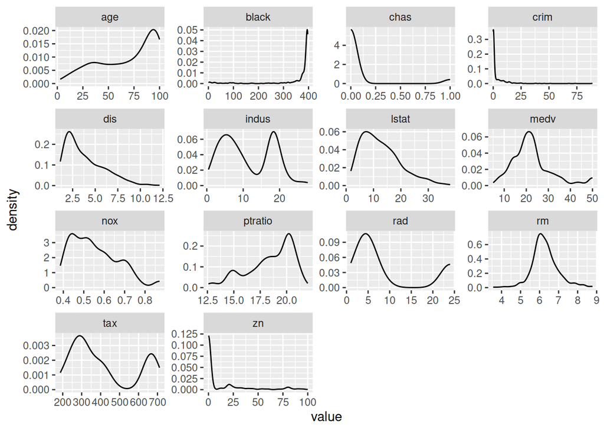

```r
# access the tidyverse libraries tidyr, dplyr, ggplot2
library(tidyr); library(dplyr); library(ggplot2);
# plot the distributions as densities
Boston %>% gather %>% ggplot(aes(value)) + facet_wrap("key", scales = "free") + geom_density()
```

In the distribution plots, I can see that at least the distribution of `rm` is somewhat normally distributed, while the others are far from a normal distribution. Most of the distributions are positively skewed: `chas`, `crim`, `dis`, `lstat`, `medv`, `nox`, and `zn`. On the other hand, `age` and `black` are negatively skewed. Further, three distributions have double peaks: `indus`, `rad`, and `tax`.

Now that we know how the variables are distributed, let’s consider the correlations between them and create a correlation matrix by using the function `cor` and rounding the resulting numbers to 2-decimal precision:

```r
# calculate the correlation matrix and round it
cor_matrix <- cor(Boston) %>% round(2)

# print the correlation matrix
cor_matrix
```

```
##          crim    zn indus  chas   nox    rm   age   dis   rad   tax ptratio
## crim     1.00 -0.20  0.41 -0.06  0.42 -0.22  0.35 -0.38  0.63  0.58    0.29
## zn      -0.20  1.00 -0.53 -0.04 -0.52  0.31 -0.57  0.66 -0.31 -0.31   -0.39
## indus    0.41 -0.53  1.00  0.06  0.76 -0.39  0.64 -0.71  0.60  0.72    0.38
## chas    -0.06 -0.04  0.06  1.00  0.09  0.09  0.09 -0.10 -0.01 -0.04   -0.12
## nox      0.42 -0.52  0.76  0.09  1.00 -0.30  0.73 -0.77  0.61  0.67    0.19
## rm      -0.22  0.31 -0.39  0.09 -0.30  1.00 -0.24  0.21 -0.21 -0.29   -0.36
## age      0.35 -0.57  0.64  0.09  0.73 -0.24  1.00 -0.75  0.46  0.51    0.26
## dis     -0.38  0.66 -0.71 -0.10 -0.77  0.21 -0.75  1.00 -0.49 -0.53   -0.23
## rad      0.63 -0.31  0.60 -0.01  0.61 -0.21  0.46 -0.49  1.00  0.91    0.46
## tax      0.58 -0.31  0.72 -0.04  0.67 -0.29  0.51 -0.53  0.91  1.00    0.46
## ptratio  0.29 -0.39  0.38 -0.12  0.19 -0.36  0.26 -0.23  0.46  0.46    1.00
## black   -0.39  0.18 -0.36  0.05 -0.38  0.13 -0.27  0.29 -0.44 -0.44   -0.18
## lstat    0.46 -0.41  0.60 -0.05  0.59 -0.61  0.60 -0.50  0.49  0.54    0.37
## medv    -0.39  0.36 -0.48  0.18 -0.43  0.70 -0.38  0.25 -0.38 -0.47   -0.51
##         black lstat  medv
## crim    -0.39  0.46 -0.39
## zn       0.18 -0.41  0.36
## indus   -0.36  0.60 -0.48
## chas     0.05 -0.05  0.18
## nox     -0.38  0.59 -0.43
## rm       0.13 -0.61  0.70
## age     -0.27  0.60 -0.38
## dis      0.29 -0.50  0.25
## rad     -0.44  0.49 -0.38
## tax     -0.44  0.54 -0.47
## ptratio -0.18  0.37 -0.51
## black    1.00 -0.37  0.33
## lstat   -0.37  1.00 -0.74
## medv     0.33 -0.74  1.00
```

To illustrate the correlations between the variables in a more visual manner, I plot the above matrix using the `corrplot` function from the `corrplot` library,

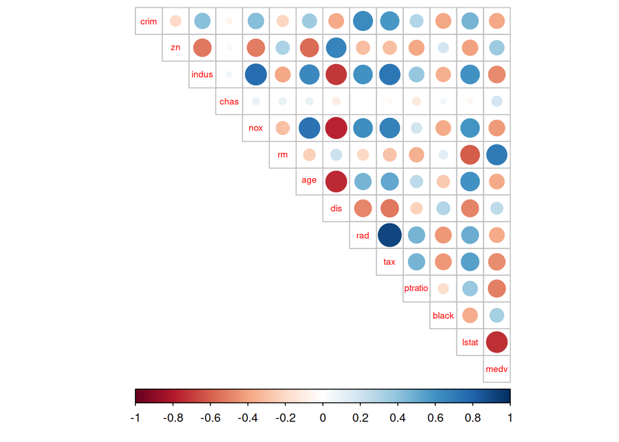

```r
# visualize the correlation matrix
library(corrplot)
corrplot(cor_matrix, method="circle", type="upper", cl.pos="b", tl.pos = "d", tl.cex=0.6)
```

As seen in the correlation plot, `rad` and `tax` have the strongest correlation, which indicates that properties that have a good access to radial highways have higher tax rates. Second highest correlation is between `indus` and `nox`, which makes sense since industry might produce nitrogen oxides. The strongest anti-correlation, however, is between `dis` and `nox` indicating that there are less nitrogen oxides at residences further away from the employment centers. The second highest anti-correlation is between `age` and `dis` meaning that residences near employment centers are typically older.

## Creating train and test sets

Next, I create train and test sets for studying the `crim` variable. First, I standardize the data set using the `scale` function which subtracts the column means from the corresponding columns and divides the difference with standard deviation, i.e.

$$\text{scaled}(X) = \frac{X-\text{mean}(X)}{\text{sd}(X)}.$$

Scaling the variables and printing out the summaries yields

```r
# center and standardize variables
boston_scaled <- Boston %>% scale

# summaries of the scaled variables
boston_scaled %>% summary
```

```
##       crim                 zn               indus              chas
##  Min.   :-0.419367   Min.   :-0.48724   Min.   :-1.5563   Min.   :-0.2723
##  1st Qu.:-0.410563   1st Qu.:-0.48724   1st Qu.:-0.8668   1st Qu.:-0.2723
##  Median :-0.390280   Median :-0.48724   Median :-0.2109   Median :-0.2723
##  Mean   : 0.000000   Mean   : 0.00000   Mean   : 0.0000   Mean   : 0.0000
##  3rd Qu.: 0.007389   3rd Qu.: 0.04872   3rd Qu.: 1.0150   3rd Qu.:-0.2723
##  Max.   : 9.924110   Max.   : 3.80047   Max.   : 2.4202   Max.   : 3.6648
##       nox                rm               age               dis
##  Min.   :-1.4644   Min.   :-3.8764   Min.   :-2.3331   Min.   :-1.2658
##  1st Qu.:-0.9121   1st Qu.:-0.5681   1st Qu.:-0.8366   1st Qu.:-0.8049
##  Median :-0.1441   Median :-0.1084   Median : 0.3171   Median :-0.2790
##  Mean   : 0.0000   Mean   : 0.0000   Mean   : 0.0000   Mean   : 0.0000
##  3rd Qu.: 0.5981   3rd Qu.: 0.4823   3rd Qu.: 0.9059   3rd Qu.: 0.6617
##  Max.   : 2.7296   Max.   : 3.5515   Max.   : 1.1164   Max.   : 3.9566
##       rad               tax             ptratio            black
##  Min.   :-0.9819   Min.   :-1.3127   Min.   :-2.7047   Min.   :-3.9033
##  1st Qu.:-0.6373   1st Qu.:-0.7668   1st Qu.:-0.4876   1st Qu.: 0.2049
##  Median :-0.5225   Median :-0.4642   Median : 0.2746   Median : 0.3808
##  Mean   : 0.0000   Mean   : 0.0000   Mean   : 0.0000   Mean   : 0.0000
##  3rd Qu.: 1.6596   3rd Qu.: 1.5294   3rd Qu.: 0.8058   3rd Qu.: 0.4332
##  Max.   : 1.6596   Max.   : 1.7964   Max.   : 1.6372   Max.   : 0.4406
##      lstat              medv
##  Min.   :-1.5296   Min.   :-1.9063
##  1st Qu.:-0.7986   1st Qu.:-0.5989
##  Median :-0.1811   Median :-0.1449
##  Mean   : 0.0000   Mean   : 0.0000
##  3rd Qu.: 0.6024   3rd Qu.: 0.2683
##  Max.   : 3.5453   Max.   : 2.9865
```

```r
# class of the boston_scaled object
class(boston_scaled)
```

```
## [1] "matrix" "array"
```

```r
# change the object to data frame
boston_scaled <- as.data.frame(boston_scaled)
```

To proceed, I create a categorical variable `crime` from the variable `crim` using the quantiles as the break points. Then I remove `crim` from the data set and add there the new categorical variable `crime`,

```r
# create a quantile vector of crim and print it
bins <- quantile(boston_scaled$crim)
bins
```

```
##           0%          25%          50%          75%         100%
## -0.419366929 -0.410563278 -0.390280295  0.007389247  9.924109610
```

```r
# create a categorical variable 'crime'
crime <- cut(boston_scaled$crim, breaks = bins, include.lowest = TRUE, label = c("low", "med_low", "med_high", "high"))

# look at the table of the new factor crime
table(crime)
```

```
## crime
##      low  med_low med_high     high
##      127      126      126      127
```

```r
# remove original crim from the dataset
boston_scaled <- dplyr::select(boston_scaled, -crim)

# add the new categorical value to scaled data
boston_scaled <- data.frame(boston_scaled, crime)
```

Finally, I divide the data set into train and test sets sot that 80% of the data belongs to the train set,

```r
# number of rows in the Boston dataset
n <- nrow(boston_scaled)

# fix the seed for reproducibility
set.seed(12321)

# choose randomly 80% of the rows
ind <- sample(n,  size = n * 0.8)

# create train set
train <- boston_scaled[ind,]

# create test set
test <- boston_scaled[-ind,]
```

## Fitting the LDA model

Next, I fit a linear discriminant analysis (LDA) model to the train set using `crime` as the target variable and all the other variables as predictors. The model finds the (linear) combination of the variables that separate the four classes of `crime`. The result of the fit is

```r
# linear discriminant analysis
lda.fit <- lda(crime ~ ., data = train)

# print the lda.fit object
lda.fit
```

```
## Call:
## lda(crime ~ ., data = train)
##
## Prior probabilities of groups:
##       low   med_low  med_high      high
## 0.2475248 0.2400990 0.2648515 0.2475248
##
## Group means:
##                  zn      indus         chas        nox         rm        age
## low       0.9437842 -0.8977495 -0.114845058 -0.8756394  0.4414575 -0.8623404
## med_low  -0.1084185 -0.2764991  0.011791568 -0.5528778 -0.1395891 -0.2610442
## med_high -0.3654210  0.1583590  0.242805543  0.3999245  0.1665618  0.3540541
## high     -0.4872402  1.0171519  0.003267949  1.1083666 -0.4254869  0.8137487
##                 dis        rad        tax     ptratio      black       lstat
## low       0.8903919 -0.6867152 -0.7459316 -0.41457560  0.3882657 -0.77496367
## med_low   0.3413025 -0.5556360 -0.5111911 -0.02231793  0.3158068 -0.10597508
## med_high -0.3724189 -0.3893910 -0.3042329 -0.35761878  0.1122724 -0.04224321
## high     -0.8575134  1.6377820  1.5138081  0.78037363 -0.7962215  0.88438347
##                  medv
## low       0.532906188
## med_low   0.001252957
## med_high  0.249560192
## high     -0.738689729
##
## Coefficients of linear discriminants:
##                 LD1          LD2         LD3
## zn       0.13849407  0.811336407 -0.84916150
## indus   -0.01049539 -0.110211684  0.27066791
## chas    -0.06471987 -0.080022418  0.13356753
## nox      0.40707035 -0.719501411 -1.42064698
## rm      -0.09593902 -0.078873876 -0.17987919
## age      0.25056541 -0.224804289  0.07174938
## dis     -0.11780950 -0.237475663  0.21149550
## rad      2.96814349  1.112608968 -0.10344537
## tax      0.02030172 -0.330852182  0.52109265
## ptratio  0.13023807  0.070820115 -0.20502516
## black   -0.13867511 -0.008657768  0.07079934
## lstat    0.23192966 -0.257595151  0.40662470
## medv     0.20888095 -0.399812637 -0.19088121
##
## Proportion of trace:
##    LD1    LD2    LD3
## 0.9448 0.0411 0.0141
```

The resulting LDA model can be plotted as a biplot by first creating a function for `lda.arrows` and then plotting `lda.fit` with the created arrows,

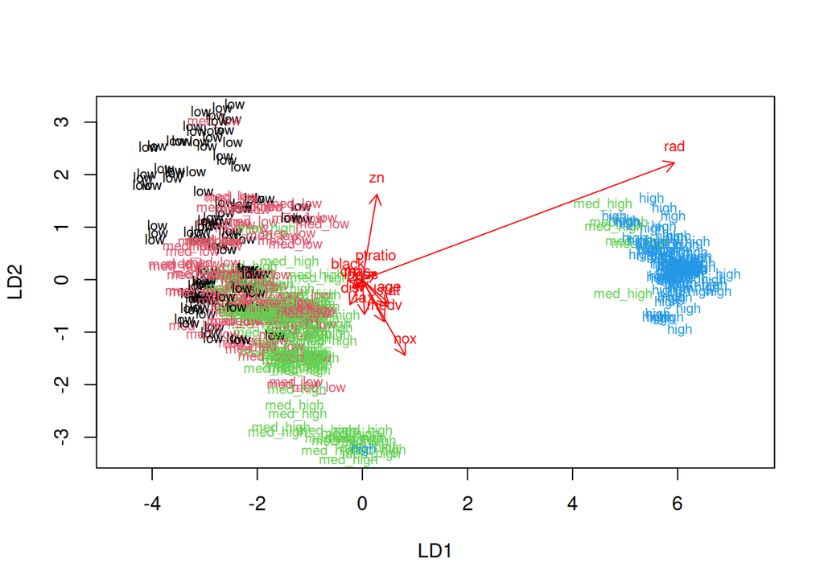

```r
# the function for lda biplot arrows
lda.arrows <- function(x, myscale = 1, arrow_heads = 0.1, color = "red", tex = 0.75, choices = c(1,2)){
  heads <- coef(x)
  graphics::arrows(x0 = 0, y0 = 0,
         x1 = myscale * heads[,choices[1]],
         y1 = myscale * heads[,choices[2]], col=color, length = arrow_heads)
  text(myscale * heads[,choices], labels = row.names(heads),
       cex = tex, col=color, pos=3)
}

# target classes as numeric
classes <- as.numeric(train$crime)

# plot the lda results (select both lines and execute them at the same time!)
plot(lda.fit, dimen = 2, col = classes, pch = classes)
lda.arrows(lda.fit, myscale = 2)
```

## Predicting with the LDA model

Now that I have the LDA model, I can use it to predict crime rates from the other variables. To do that, I first save and remove the correct crime categories from the test set,

```r
# save the correct classes from test data
correct_classes <- test$crime

# remove the crime variable from test data
test <- dplyr::select(test, -crime)
```

Now, I can use `lda.pred` to predict the categorical crime rates of the test set and cross-tabulate the predicted results with the correct crime rates that I just saved,

```r
# predict classes with test data
lda.pred <- predict(lda.fit, newdata = test)

# cross tabulate the results
table(correct = correct_classes, predicted = lda.pred$class)
```

```
##           predicted
## correct    low med_low med_high high
##   low       17       8        2    0
##   med_low    8      16        5    0
##   med_high   0       8       11    0
##   high       0       0        0   27
```